# app structure

### Objective

- Provide several tools to support selection ofbiowastes and/or biowaste mixtures.

### Target audience

- Black soldier fly larvae biowaste processing operators

### Data

- App initial based on data summarized in .csv/.xlsx files. In future consider a function to upload data by app user.
- Biowaste nutrient composition data:

```r
biowaste_nutrients <- read.xlsx(xlsxFile =here::here("data/waste_sum.xlsx"),sheet = 1)
performance <- read.xlsx(xlsxFile =here::here("data/performance_sum.xlsx"),sheet = 1)
```

### Tools & objective

1. Illustrate (dis)similartiy between biowaste nutrient composition with PCA biplot. Objective: Users broadly understands that biowastes have different nutrient contents, so user can place biowastes into broad categories.
2. Summarise descriptive statistics for different nutrients and biowastes. Objective: Users can get detailed data on different nutrients for different biowastes. User understands detailed nutrient contents between biowastes.
3. Calculate nutrients contents for different biowaste formulations. Objective: User can identify the nutrient content of a biowaste mixture based on the percentage of the individual components.
4. Summarize process performance data (i.e. bioconversion rate, waste reduction) for different biowastes. Objective: User gets detailed on performance with different biowastes.

### Overarching design

- Tools can be accessed using different tabs on the top, e.g. `navbarPage()`
- Alternatives
  - Tools 2 and 3 could potentially be combined under one tab
  - Tool 1-3 (Biowaste formulation) and Tool 4 (Performance data) could also be combined under one tab with `navbarMenu()`.

### Tool 1: Big-picture biowaste nutrient composition

- I want to silence the output of the code junk below (but run the code). Could not figure it out.

```r
# remove missing data (PCA only works when each parameter has a value for each parameter)

biowaste_nutrients_slim <-

biowaste_nutrients %>%

  select(-Glucose,-Starch,-Ash_insoluable) %>%

  na.omit()


# remove columns with data description

biowaste_nutrients_clean <-

biowaste_nutrients_slim %>%

  select(7:11)


# run PCA

pca_biowaste_nutrients <- PCA(biowaste_nutrients_clean,scale.unit=TRUE)
```

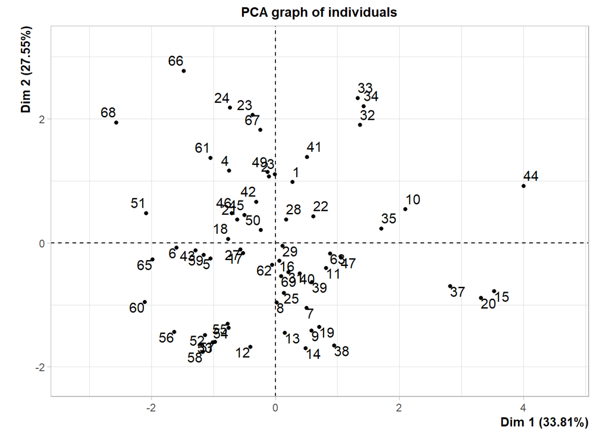

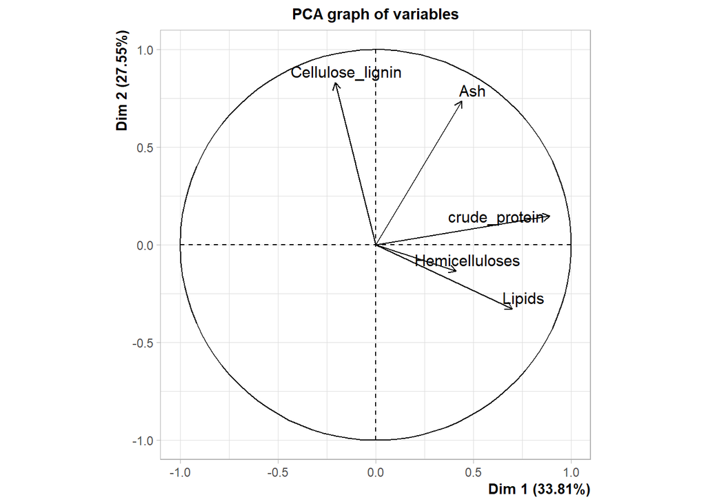

- This could be the output of tool 1.
- The input of tool 1 would be a playing around with the columns of *biowaste_nutrients_slim*, e.g. with `radioButtons()`. Only once selection allowed.
  - Diet_group_detailed
  - Diet_group
  - Performance

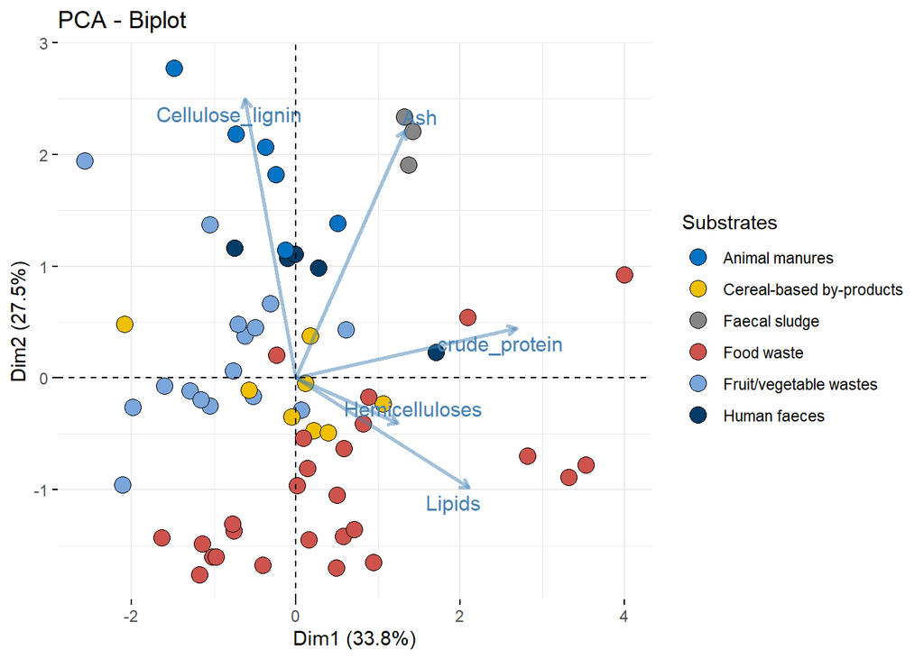

```r
# produce biplot using PCA results

fviz_pca_biplot(pca_biowaste_nutrients,
                geom.ind = "point",
                fill.ind = biowaste_nutrients_slim$Diet_group,
                pointshape = 21, pointsize = 4,
                palette = "jco",
                ggtheme = theme_minimal(),
                arrowsize = 1,
                labelsize = 4,
                mean.point = FALSE,
                legend.title = "Substrates",
                alpha.var=0.5,
                repel = TRUE)
```

### Tool 2: Detailed summary biowaste nutrients

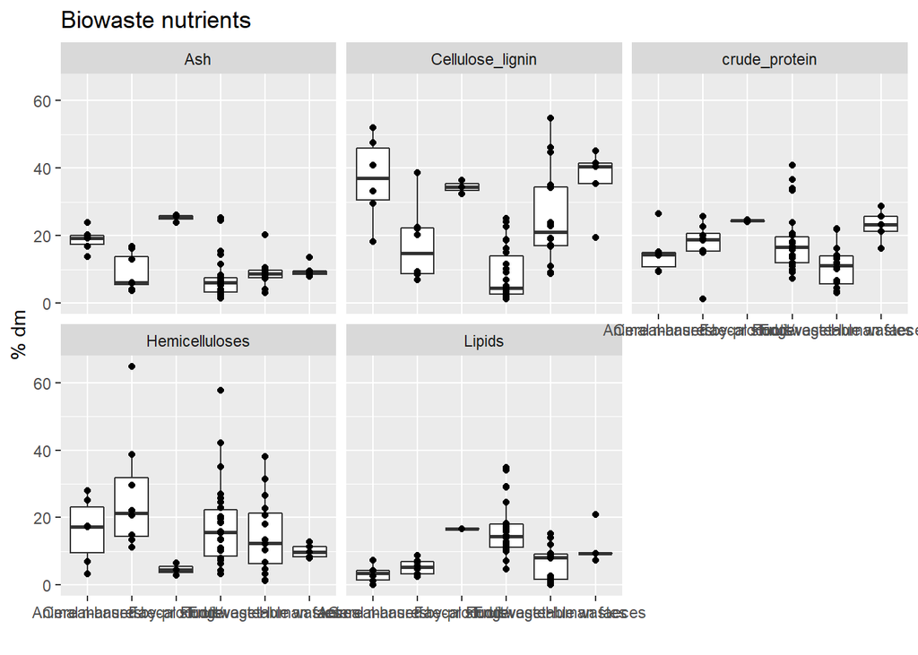

```r
# gather biowaste_nutrients_slim

biowaste_nutrients_slim_narrow <-

biowaste_nutrients_slim %>%

  gather(7:11,key = parameter,value = value)


biowaste_nutrients_slim_narrow %>%

 ggplot(aes(Diet_group,value)) +

            geom_boxplot() +

            geom_point() +

            labs(y = "% dm", x="", title = "Biowaste nutrients") +

            facet_wrap(~parameter)
```

- The first output would a boxplot.
- The input would be `checkboxGroupInput` both for `levels(biowaste_nutrients_slim$Diet_group)` and `levels(biowaste_nutrients_slim_narrow$parameter)`. This way the user can only select the diet group and parameter of interest and is not overwhelmed.
- The second output should be a table based on the two `checkboxGroupInput`. The user should be able to download this table as an MS Excel sheet.

### Tool 3: Biowaste formulation

- This is the tricky tool.
- We want that users the final nutrient content of a mixture of different biowastes (max. 4).
- The final nutrient content of the biowaste mixture for each nutrient is the sum of the biowaste proportions of the different constituents times the mean nutrient content of the constituents.
- Users should select the biowastes they would would like to mix together with `checkboxGroupInput()`. Following, they should chose the proportions of the different wastes, e.g. with `sliderInput()` or `numericInput`. This sum of the proportions always needs add up to 1. So if the the sum of `sliderInput()` or `numericInput` is < 1 or > 1 it needs to print a message.
- The output should be a table and plot (x=Nutrient, y=Nutrient content) showing the formulation.
- I am still trying to find out what the standard deviation of the biowaste mixture is, based on deviation from the mean for each nutrient and Diet_group (see Tool 2).

### Tool 4: Process performance summary

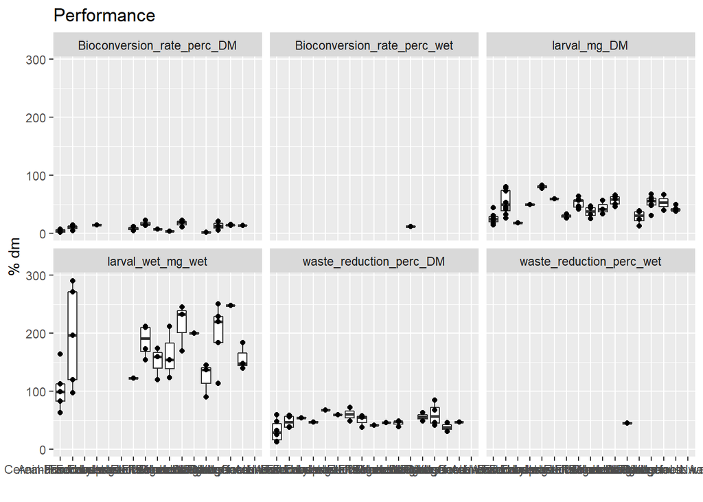

```r
performance_narrow <-

performance %>%

  gather(11:16,key = parameter,value = value)


performance_narrow %>%

 ggplot(aes(Diet_group,value)) +

            geom_boxplot() +

            geom_point() +

            labs(y = "% dm", x="", title = "Performance") +

            facet_wrap(~parameter)
```

- Basically this should just be a summary of the performance data. Chris would just be happy with a table that is displayed and can be downloaded. I think additonally the user should be able to show discriptive statistics (similat to tool 2).
- The different performance values were produced under vary different experimental conditons. It would be nice to give the use the possibility to show that additonal information, but it should be not in the default table because I think it would make it too messy. Unfortunately, not the same parameter is available for each entry, complicating things. I was hoping we can just use `unite()`and than add the column name before each experimental parameter.
- The same as for the experimental conditions also applies for the compounds. So far the table includes mostly pure wastes, but we will get more data of biowaste mixtures. The user needs to see the compounds of the mixture (in %).
- It maybe makes sense to otherwise keep the inputs/outputs similar to tool 2. The input would be `checkboxGroupInput` both for `levels(performance_narrow$Diet_group)` and `levels(performance_narrow$parameter)`. This way the user can only select the diet group and parameter of interest and is not overwhelmed.
- The first output would a boxplot.
- The second output should be a table based on the two `checkboxGroupInput`. The user should be able to download this table as an MS Excel sheet.